# Impact analysis of weather events on population health and economy in US

## Data Processing

### Load Packages

```r
packages <- c("data.table", "ggplot2")
sapply(packages, require, character.only=TRUE, quietly=TRUE)
```

```
## data.table    ggplot2
##       TRUE       TRUE
```

### Read data file

The data file (CSV format) is in the working directory. Read the CSV file as a data frame. Then convert to a data table.

```r
f <- file.path(getwd(), "repdata-data-StormData.csv.bz2")
con <- bzfile(f)
dt <- read.csv(con, stringsAsFactors=FALSE)
dt <- data.table(dt)
str(dt)
```

```
## Classes 'data.table' and 'data.frame':   902297 obs. of  37 variables:
##  $ STATE__   : num  1 1 1 1 1 1 1 1 1 1 ...
##  $ BGN_DATE  : chr  "4/18/1950 0:00:00" "4/18/1950 0:00:00" "2/20/1951 0:00:00" "6/8/1951 0:00:00" ...
##  $ BGN_TIME  : chr  "0130" "0145" "1600" "0900" ...
##  $ TIME_ZONE : chr  "CST" "CST" "CST" "CST" ...
##  $ COUNTY    : num  97 3 57 89 43 77 9 123 125 57 ...
##  $ COUNTYNAME: chr  "MOBILE" "BALDWIN" "FAYETTE" "MADISON" ...
##  $ STATE     : chr  "AL" "AL" "AL" "AL" ...
##  $ EVTYPE    : chr  "TORNADO" "TORNADO" "TORNADO" "TORNADO" ...
##  $ BGN_RANGE : num  0 0 0 0 0 0 0 0 0 0 ...
##  $ BGN_AZI   : chr  "" "" "" "" ...
##  $ BGN_LOCATI: chr  "" "" "" "" ...
##  $ END_DATE  : chr  "" "" "" "" ...
##  $ END_TIME  : chr  "" "" "" "" ...
##  $ COUNTY_END: num  0 0 0 0 0 0 0 0 0 0 ...
```

[output cut: 24 more lines]

### Clean Data

List the number of unique values of `evtype`.

```r
message(sprintf("Number of unique values of evtype: %.0d", length(unique(dt$EVTYPE))))
```

```
## Number of unique values of evtype: 985
```

Since there are a large number of unique event types, the top 20 events are considered for each scenario.

Create a subset of the data with the needed attributes

```r
stormDt <- dt[,c("EVTYPE","FATALITIES","INJURIES","PROPDMG","PROPDMGEXP","CROPDMG","CROPDMGEXP")]
```

Calculate the total number of fatalities and injuries

```r
stormDt$TOTAL_INCIDENTS <- stormDt$FATALITIES + stormDt$INJURIES
```

Aggregate the total incidents per event type and pick the top 20.

```r
stormDtHealthHazards <- stormDt[, list(HEALTH_HAZARDS = sum(TOTAL_INCIDENTS)),EVTYPE]
top20HealthHazards <- stormDtHealthHazards[order(stormDtHealthHazards$HEALTH_HAZARDS, decreasing = TRUE), ][1:20, ]
```

Convert the PROPDMGEXP and CROPDMGEXP into number as below:

- B - Billion, M - Million, K - 1000, H - 100, all others = 1

**Property Damage:** Calculate the PROPDMG_VALUE as PROPDMG * PROPDMGEXP; Aggregate PROPDMG_VALUE per event type and pick the top 20.

**Crop Damage:** Calculate the CROPDMG_VALUE as CROPDMG * CROPDMGEXP; Aggregate CROPDMG_VALUE per event type and pick the top 20.

```r
stormDt$PROPDMGEXP[stormDt$PROPDMGEXP == "B"] <- 1e+09
stormDt$PROPDMGEXP[stormDt$PROPDMGEXP == "h"] <- 100
stormDt$PROPDMGEXP[stormDt$PROPDMGEXP == "H"] <- 100
stormDt$PROPDMGEXP[stormDt$PROPDMGEXP == "K"] <- 1000
stormDt$PROPDMGEXP[stormDt$PROPDMGEXP == "m"] <- 1e+06
stormDt$PROPDMGEXP[stormDt$PROPDMGEXP == "M"] <- 1e+06
stormDt$PROPDMGEXP[!stormDt$PROPDMGEXP %in% c("M","m","K","H","h","B")] <- 1

stormDt$CROPDMGEXP[stormDt$CROPDMGEXP == "B"] <- 1e+09
stormDt$CROPDMGEXP[stormDt$CROPDMGEXP == "K"] <- 1000
stormDt$CROPDMGEXP[stormDt$CROPDMGEXP == "m"] <- 1e+06
stormDt$CROPDMGEXP[stormDt$CROPDMGEXP == "M"] <- 1e+06
stormDt$CROPDMGEXP[!stormDt$CROPDMGEXP %in% c("M","m","K","B")] <- 1

stormDt$totalpropdamage <- as.numeric(stormDt$PROPDMGEXP) * (stormDt$PROPDMG)
totalPropDmg <- aggregate(stormDt$totalpropdamage, by = list(stormDt$EVTYPE), sum)
totalPropDmg <- stormDt[, list(PROPDMG_VALUE = sum(totalpropdamage)),EVTYPE]
top20PropDmg <- totalPropDmg[order(totalPropDmg$PROPDMG_VALUE, decreasing = TRUE, na.last = NA), ][1:20, ]


stormDt$totalcropdamage <- as.numeric(stormDt$CROPDMGEXP) * stormDt$CROPDMG
totalCropDmg <- aggregate(stormDt$totalcropdamage, by = list(stormDt$EVTYPE),
    sum)
totalCropDmg <- stormDt[, list(CROPDMG_VALUE = sum(totalcropdamage)),EVTYPE]

top20CropDmg <- totalCropDmg[order(totalCropDmg$CROPDMG_VALUE, decreasing = TRUE, na.last = NA), ][1:20, ]
```

## Results

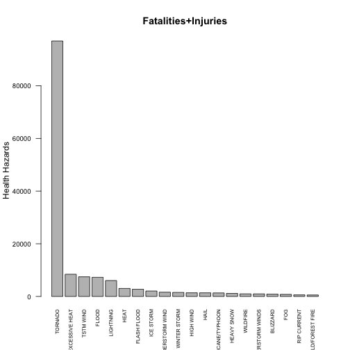

```r
barplot(top20HealthHazards$HEALTH_HAZARDS, names.arg = top20HealthHazards$EVTYPE, main = "Fatalities+Injuries", ylab = "Health Hazards", cex.axis = 0.8, cex.names = 0.6, las = 2)
```

The above chart clearly indicates the top 20 events that greatly impact the population health. **Tornado affects the population health the most.**

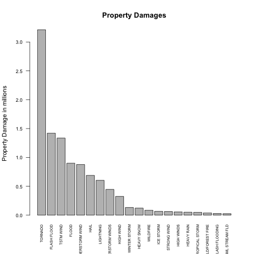

```r
barplot(top20PropDmg$PROPDMG_VALUE/10^6, names.arg = top20PropDmg$EVTYPE, main = "Property Damages", ylab = "Property Damage in millions", cex.axis = 0.8, cex.names = 0.6, las = 2)
```

The above chart displays the top 20 events that have inflicted property damage. **Tornado creates the maximum property damage.**

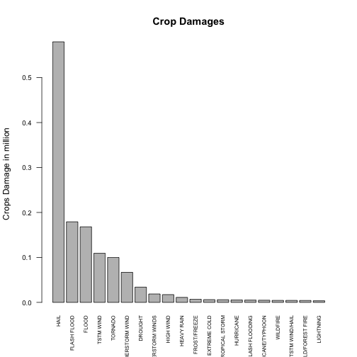

```r
barplot(top20CropDmg$CROPDMG_VALUE/10^6, names.arg = top20CropDmg$EVTYPE, main = "Crop Damages", ylab = "Crops Damage in million", cex.axis = 0.8, cex.names = 0.6, las = 2)
```

The above chart displays the top 20 events that have inflicted crop damage. **Hail creates the maximum crop damage.**